# Getting started with `sparklyr`

```r
library("sparklyr")
sc <- spark_connect(master = "local", version = "2.4.5")
```

```r
library(tidyverse)
library(dbplot)
library(corrr)
library(rmarkdown)
```

```r
cars <- copy_to(sc, mtcars)
```

```r
cars %>%
  summarise_all(mean)
```

```
Missing values are always removed in SQL.
Use `mean(x, na.rm = TRUE)` to silence this warning
```

| mpg | cyl | disp | hp | drat | wt | qsec | vs | am | gear | carb |
| --- | --- | --- | --- | --- | --- | --- | --- | --- | --- | --- |
| 20.09062 | 6.1875 | 230.7219 | 146.6875 | 3.596563 | 3.21725 | 17.84875 | 0.4375 | 0.40625 | 3.6875 | 2.8125 |

```r
cars %>%
  summarise_all(var) %>%
  show_query()
```

```
<SQL>
SELECT var_samp(`mpg`) AS `mpg`, var_samp(`cyl`) AS `cyl`, var_samp(`disp`) AS `disp`, var_samp(`hp`) AS `hp`, var_samp(`drat`) AS `drat`, var_samp(`wt`) AS `wt`, var_samp(`qsec`) AS `qsec`, var_samp(`vs`) AS `vs`, var_samp(`am`) AS `am`, var_samp(`gear`) AS `gear`, var_samp(`carb`) AS `carb`
FROM `mtcars`
```

```r
cars %>%
  mutate(shift_type = ifelse(am == 0, "automatic", "manual")) %>%
  group_by(shift_type) %>%
  summarise_all(mean)
```

| shift_type | mpg | cyl | disp | hp | drat | wt | qsec | vs | am | gear | carb |
| --- | --- | --- | --- | --- | --- | --- | --- | --- | --- | --- | --- |
| manual | 24.39231 | 5.076923 | 143.5308 | 126.8462 | 4.050000 | 2.411000 | 17.36000 | 0.5384615 | 1 | 4.384615 | 2.923077 |
| automatic | 17.14737 | 6.947368 | 290.3789 | 160.2632 | 3.286316 | 3.768895 | 18.18316 | 0.3684211 | 0 | 3.210526 | 2.736842 |

```r
cars %>%
  mutate(shift_type = ifelse(am == 0, "automatic", "manual")) %>%
  group_by(shift_type) %>%
  summarise_all(mean) %>%
  show_query()
```

```
<SQL>
SELECT `shift_type`, AVG(`mpg`) AS `mpg`, AVG(`cyl`) AS `cyl`, AVG(`disp`) AS `disp`, AVG(`hp`) AS `hp`, AVG(`drat`) AS `drat`, AVG(`wt`) AS `wt`, AVG(`qsec`) AS `qsec`, AVG(`vs`) AS `vs`, AVG(`am`) AS `am`, AVG(`gear`) AS `gear`, AVG(`carb`) AS `carb`
FROM (SELECT `mpg`, `cyl`, `disp`, `hp`, `drat`, `wt`, `qsec`, `vs`, `am`, `gear`, `carb`, CASE WHEN (`am` = 0.0) THEN ("automatic") WHEN NOT(`am` = 0.0) THEN ("manual") END AS `shift_type`
FROM `mtcars`) `dbplyr_003`
GROUP BY `shift_type`
```

## `select` works but square bracket subsetting does not

```r
cars %>%
  select(mpg, cyl)
```

| mpg | cyl |
| --- | --- |
| 21.0 | 6 |
| 21.0 | 6 |
| 22.8 | 4 |
| 21.4 | 6 |
| 18.7 | 8 |
| 18.1 | 6 |
| 14.3 | 8 |
| 24.4 | 4 |
| 22.8 | 4 |
| 19.2 | 6 |

[output cut: 22 more lines]

```r
tryCatch(
  {cars[, c("mpg", "cyl")]},
  error = print
)
```

```
<simpleError in cars[, c("mpg", "cyl")]: incorrect number of dimensions>
```

## Using Spark built-in functions inside `dplyr`

percentile, array and explode are Spark functions (technically Hive functions - Apache Hive is a data warehousing system that provides SQL-like syntax to interrogate data held in files and databases)

```r
cars %>%
  summarise(mpg_percentile = percentile(mpg, array(0.25, 0.5, 0.75))) %>%
  mutate(mpg_percentile = explode(mpg_percentile))
```

| mpg_percentile |
| --- |
| 15.425 |
| 19.200 |
| 22.800 |

```r
NA
```

## Correlations

```r
library(corrr)
cars %>%
  correlate(use = "pairwise.complete.obs", method = "pearson")
```

```
The `x` argument of `as_tibble.matrix()` must have column names if `.name_repair` is omitted as of tibble 2.0.0.
Using compatibility `.name_repair`.
Correlation method: 'pearson'
Missing treated using: 'pairwise.complete.obs'
```

| rowname | mpg | cyl | disp | hp | drat | wt | qsec | vs | am | gear | carb |
| --- | --- | --- | --- | --- | --- | --- | --- | --- | --- | --- | --- |
| mpg | NA | -0.8521620 | -0.8475514 | -0.7761684 | 0.68117191 | -0.8676594 | 0.41868403 | 0.6640389 | 0.59983243 | 0.4802848 | -0.55092507 |
| cyl | -0.8521620 | NA | 0.9020329 | 0.8324475 | -0.69993811 | 0.7824958 | -0.59124207 | -0.8108118 | -0.52260705 | -0.4926866 | 0.52698829 |
| disp | -0.8475514 | 0.9020329 | NA | 0.7909486 | -0.71021393 | 0.8879799 | -0.43369788 | -0.7104159 | -0.59122704 | -0.5555692 | 0.39497686 |
| hp | -0.7761684 | 0.8324475 | 0.7909486 | NA | -0.44875912 | 0.6587479 | -0.70822339 | -0.7230967 | -0.24320426 | -0.1257043 | 0.74981247 |
| drat | 0.6811719 | -0.6999381 | -0.7102139 | -0.4487591 | NA | -0.7124406 | 0.09120476 | 0.4402785 | 0.71271113 | 0.6996101 | -0.09078980 |
| wt | -0.8676594 | 0.7824958 | 0.8879799 | 0.6587479 | -0.71244065 | NA | -0.17471588 | -0.5549157 | -0.69249526 | -0.5832870 | 0.42760594 |
| qsec | 0.4186840 | -0.5912421 | -0.4336979 | -0.7082234 | 0.09120476 | -0.1747159 | NA | 0.7445354 | -0.22986086 | -0.2126822 | -0.65624923 |
| vs | 0.6640389 | -0.8108118 | -0.7104159 | -0.7230967 | 0.44027846 | -0.5549157 | 0.74453544 | NA | 0.16834512 | 0.2060233 | -0.56960714 |
| am | 0.5998324 | -0.5226070 | -0.5912270 | -0.2432043 | 0.71271113 | -0.6924953 | -0.22986086 | 0.1683451 | NA | 0.7940588 | 0.05753435 |
| gear | 0.4802848 | -0.4926866 | -0.5555692 | -0.1257043 | 0.69961013 | -0.5832870 | -0.21268223 | 0.2060233 | 0.79405876 | NA | 0.27407284 |

[output cut: 1 more lines]

## Visualise

```r
cars_group <- cars %>%
  group_by(cyl) %>%
  summarise(mean_mpg = mean(mpg, na.rm = TRUE)) %>%
  collect()
```

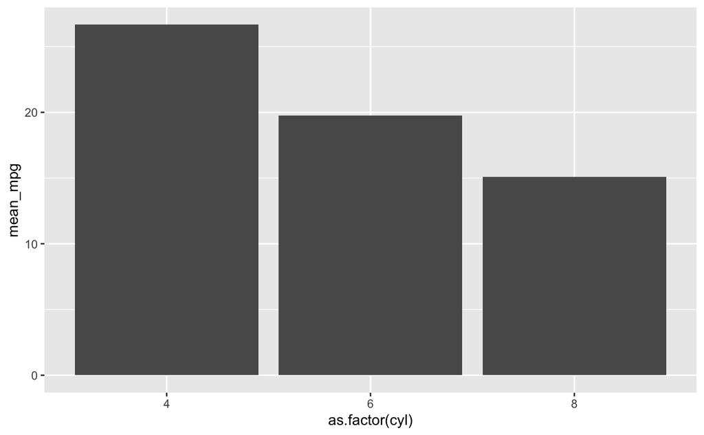

```r
cars_group %>%
  ggplot(aes(x = as.factor(cyl), y = mean_mpg)) +
  geom_col()
```

## Visualise using `dbplot`

Imagine you have a huge dataset stored on Spark from which you would like to compute and show a scatter plot of two continuous numerical variables. One strategy to do this would be to `collect()` the data from `Spark` and use regular `ggplot2` functions to plot it, but for large data this may not be possible: you may run out of memory on your local machine.

An alternative and better strategy is to **push as much of the computation for the plot as possible to Spark**. The `dbplot` package helps with this: it can push calculations for plotting to a remote database (Hive in this case), and bring back only the minimal data needed for a plot.

Of course, while this may be beneficial for a histogram (the database need only return a list of bins and counts), it is not so useful for scatter plots in which each data point appears as a point. The **raster plot** can help with this: you can think of a raster plot as being like a **binned** scatter plot, i.e. one in which the $x-$ and $y-$coordinates have been binned. Let’s see an example for `cars`.

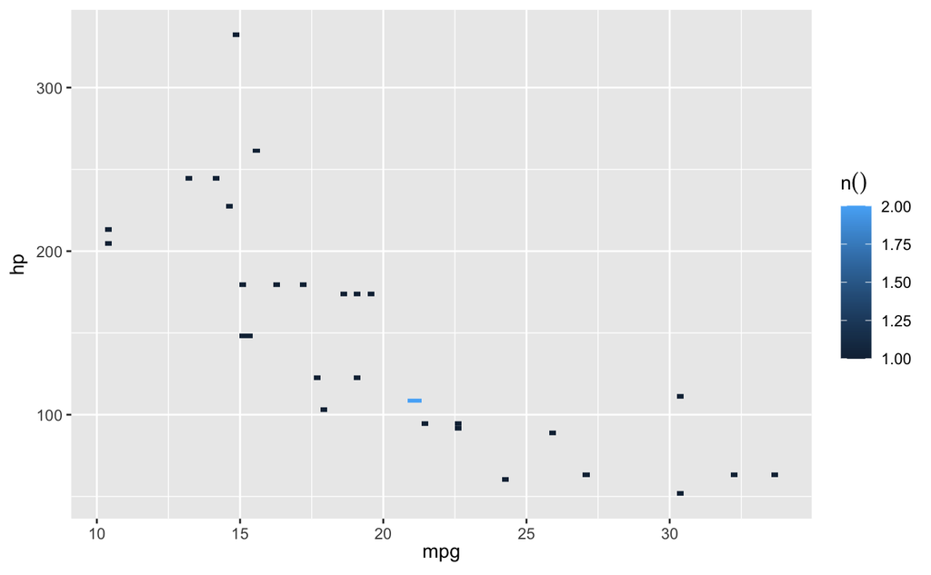

```r
library(dbplot)

cars %>%
  dbplot_raster(x = mpg, y = hp)
```

Of course, this is a rather simple example in which binning is not required. The key point here though is that the binning is being done in `Spark`, rather than in `R`. `

## Storing intermediate results in Spark using `compute()`, return to `R` using `collect()`

```r
computed <- cars %>%
  filter(disp > 180) %>%
  compute("filtered_cars")

head(computed)
```

| mpg | cyl | disp | hp | drat | wt | qsec | vs | am | gear | carb |
| --- | --- | --- | --- | --- | --- | --- | --- | --- | --- | --- |
| 21.4 | 6 | 258.0 | 110 | 3.08 | 3.215 | 19.44 | 1 | 0 | 3 | 1 |
| 18.7 | 8 | 360.0 | 175 | 3.15 | 3.440 | 17.02 | 0 | 0 | 3 | 2 |
| 18.1 | 6 | 225.0 | 105 | 2.76 | 3.460 | 20.22 | 1 | 0 | 3 | 1 |
| 14.3 | 8 | 360.0 | 245 | 3.21 | 3.570 | 15.84 | 0 | 0 | 3 | 4 |
| 16.4 | 8 | 275.8 | 180 | 3.07 | 4.070 | 17.40 | 0 | 0 | 3 | 3 |
| 17.3 | 8 | 275.8 | 180 | 3.07 | 3.730 | 17.60 | 0 | 0 | 3 | 3 |

```r
class(computed)
```

```
[1] "tbl_spark" "tbl_sql"   "tbl_lazy"  "tbl"
```

```r
results <- computed %>%
  summarise(
    mean_hp = mean(hp),
    mean_mpg = mean(mpg)
  ) %>%
  collect()

class(results)
```

```
[1] "tbl_df"     "tbl"        "data.frame"
```

```r
results
```

| mean_hp | mean_mpg |
| --- | --- |
| 196.5 | 15.68125 |

## SQL in `sparklyr`

Behind the scenes, `sparklyr` is turning your `dplyr` pipes into SQL commands it runs against the Hive metastore running alongside Spark. This means that we can, if we prefer, write SQL queries directly and run them in `R` in the way we did previously in the course

```r
library(DBI)

query <- "SELECT AVG(hp), AVG(mpg) FROM mtcars WHERE disp > 180"
dbGetQuery(sc, query)
```

| avg(hp) | avg(mpg) |
| --- | --- |
| 196.5 | 15.68125 |

# `sparklyr` native interfaces

Here ‘native’ means that these functions call Java or Scala code directly without transformation to SQL

Spark is much stricter about variable types than `R` (`R` like `Python` is a ‘dynamically typed’ language, but Spark is ‘statically typed’: variable types have to be defined ahead of time). In the majority of cases, native Spark functions take `DoubleType` inputs: this is Spark’s equivalent of an `R` `numeric`.

# MLib machine learning interface

- feature transformation functions starting `ft_`
- machine learning functions starting `ml_`

```r
ls("package:sparklyr", pattern = "^ft")
```

```
 [1] "ft_binarizer"                      "ft_bucketed_random_projection_lsh"
 [3] "ft_bucketizer"                     "ft_chisq_selector"
 [5] "ft_count_vectorizer"               "ft_dct"
 [7] "ft_discrete_cosine_transform"      "ft_dplyr_transformer"
 [9] "ft_elementwise_product"            "ft_feature_hasher"
[11] "ft_hashing_tf"                     "ft_idf"
[13] "ft_imputer"                        "ft_index_to_string"
[15] "ft_interaction"                    "ft_max_abs_scaler"
[17] "ft_min_max_scaler"                 "ft_minhash_lsh"
[19] "ft_ngram"                          "ft_normalizer"
[21] "ft_one_hot_encoder"                "ft_one_hot_encoder_estimator"
[23] "ft_pca"                            "ft_polynomial_expansion"
[25] "ft_quantile_discretizer"           "ft_r_formula"
[27] "ft_regex_tokenizer"                "ft_sql_transformer"
[29] "ft_standard_scaler"                "ft_stop_words_remover"
[31] "ft_string_indexer"                 "ft_string_indexer_model"
[33] "ft_tokenizer"                      "ft_vector_assembler"
[35] "ft_vector_indexer"                 "ft_vector_slicer"
[37] "ft_word2vec"
```

## `ft_binarizer()`

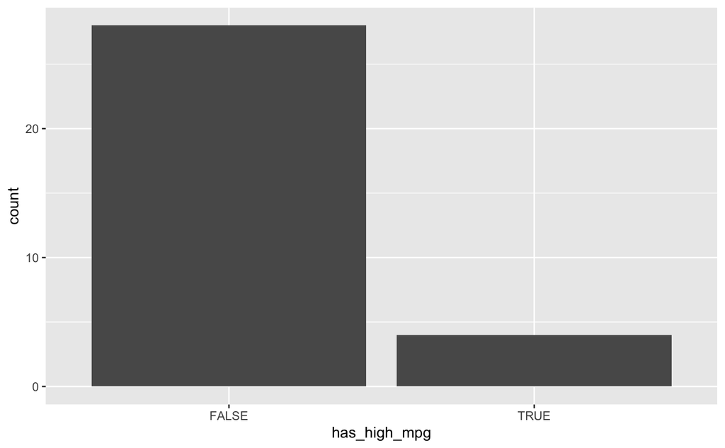

```r
high_mpg <- cars %>%
  select(mpg) %>%
  ft_binarizer("mpg", "has_high_mpg", threshold = 30) %>%
  mutate(has_high_mpg = as.logical(has_high_mpg)) %>%
  collect()

high_mpg %>%
  ggplot(aes(x = has_high_mpg)) +
  geom_bar()
```

## `ft_bucketizer()`

```r
labels <- c("10 to 20", "20 to 30", "30 to 40")
mtcars %>%
  mutate(
    mpg_buckets = cut(
      mpg,
      breaks = c(10, 20, 30, 40),
      labels = labels,
      right = FALSE,
      include.lowest = TRUE
    )
  )
```

| mpg | cyl | disp | hp | drat | wt | qsec | vs | am | gear | carb | mpg_buckets |
| --- | --- | --- | --- | --- | --- | --- | --- | --- | --- | --- | --- |
| 21.0 | 6 | 160.0 | 110 | 3.90 | 2.620 | 16.46 | 0 | 1 | 4 | 4 | 20 to 30 |
| 21.0 | 6 | 160.0 | 110 | 3.90 | 2.875 | 17.02 | 0 | 1 | 4 | 4 | 20 to 30 |
| 22.8 | 4 | 108.0 | 93 | 3.85 | 2.320 | 18.61 | 1 | 1 | 4 | 1 | 20 to 30 |
| 21.4 | 6 | 258.0 | 110 | 3.08 | 3.215 | 19.44 | 1 | 0 | 3 | 1 | 20 to 30 |
| 18.7 | 8 | 360.0 | 175 | 3.15 | 3.440 | 17.02 | 0 | 0 | 3 | 2 | 10 to 20 |
| 18.1 | 6 | 225.0 | 105 | 2.76 | 3.460 | 20.22 | 1 | 0 | 3 | 1 | 10 to 20 |
| 14.3 | 8 | 360.0 | 245 | 3.21 | 3.570 | 15.84 | 0 | 0 | 3 | 4 | 10 to 20 |
| 24.4 | 4 | 146.7 | 62 | 3.69 | 3.190 | 20.00 | 1 | 0 | 4 | 2 | 20 to 30 |
| 22.8 | 4 | 140.8 | 95 | 3.92 | 3.150 | 22.90 | 1 | 0 | 4 | 2 | 20 to 30 |
| 19.2 | 6 | 167.6 | 123 | 3.92 | 3.440 | 18.30 | 1 | 0 | 4 | 4 | 10 to 20 |

[output cut: 22 more lines]

Let’s see what `ft_bucketizer()` returns:

```r
cars %>%
  ft_bucketizer("mpg", "mpg_buckets", splits = c(10, 20, 30, 40)) %>%
  distinct(mpg_buckets) %>%
  collect()
```

| mpg_buckets |
| --- |
| 0 |
| 1 |
| 2 |

It returns buckets labelled 0, 1 and 2. We should mutate these to meaningful names, but we should **do the `count()` operation on the Spark side**, as this could be an intensive computation

```r
cars_mpg_buckets <- cars %>%
  ft_bucketizer("mpg", "mpg_buckets", splits = c(10, 20, 30, 40)) %>%
  count(mpg_buckets) %>%
  collect() %>%
  mutate(mpg_buckets = factor(mpg_buckets, labels = labels))

cars_mpg_buckets
```

| mpg_buckets | n |
| --- | --- |
| 10 to 20 | 18 |
| 20 to 30 | 10 |
| 30 to 40 | 4 |

Can also perform quantile based bucketing

```r
cars_mpg_buckets <- cars %>%
  ft_quantile_discretizer("mpg", "mpg_buckets", num_buckets = 3) %>%
  count(mpg_buckets) %>%
  collect() %>%
  mutate(mpg_buckets = factor(mpg_buckets, labels = c("low", "medium", "high")))

cars_mpg_buckets
```

| mpg_buckets | n |
| --- | --- |
| low | 10 |
| medium | 10 |
| high | 12 |

# Text data

First few paragraphs of ‘The Lord of the Rings’ and ‘The Lion, the Witch and the Wardrobe’

```r
lotr_path <- paste0("file:///", getwd(), "/lotr.txt")
lww_path <- paste0("file:///", getwd(), "/lww.txt")

lotr <- spark_read_text(sc, "lotr", lotr_path)
lww <- spark_read_text(sc, "lww", lww_path)
```

Use `sdf_bind_rows()` from Spark DataFrame API (more on this shortly) to bind these DataFrames together

```r
all_text <- lotr %>%
  mutate(author = "tolkien") %>%
  sdf_bind_rows({
    lww %>%
      mutate(author = "lewis")}) %>%
  filter(nchar(line) > 0)
```

```
`data_frame()` is deprecated as of tibble 1.1.0.
Please use `tibble()` instead.
```

Use Hive `regexp_replace()` function to remove punctuation and numbers

```r
all_text <- all_text %>%
  mutate(line = regexp_replace(line, "[_\"\'():;,.!?\\-]", " ")) %>%
  mutate(line = regexp_replace(line, "[0-9]", ""))
```

```r
all_text <- all_text %>%
  ft_tokenizer(input_col = "line", output_col = "word_list") %>%
  ft_stop_words_remover(input_col = "word_list", output_col = "no_stop_word_list")

head(all_text)
```

| line | author | word_list | no_stop_word_list |
| --- | --- | --- | --- |
| Chapter A Long Expected Party | tolkien |  |  |
| When Mr Bilbo Baggins of Bag End announced that he would shortly be celebrating | tolkien |  |  |
| his eleventy first birthday with a party of special magnificence there was much | tolkien |  |  |
| talk and excitement in Hobbiton | tolkien |  |  |
| Bilbo was very rich and very peculiar and had been the wonder of the Shire for | tolkien |  |  |
| sixty years ever since his remarkable disappearance and unexpected return The | tolkien |  |  |

`ft_tokenizer()` splits on spaces, but can also use `ft_regex_tokenizer()` to split on more complex patterns.

Note at this point that the `list`s in the `no_stop_words` column are typically smaller than the `list`s in the `word_list` column: the stop words have been removed.

```r
all_text <- all_text %>%
  select(author, no_stop_word_list) %>%
  mutate(word = explode(no_stop_word_list)) %>%
  select(-no_stop_word_list) %>%
  filter(nchar(word) > 2) %>%
  compute("all_text") # store on Spark in intermediate 'all_text' SDF
```

Most used words

```r
word_count <- all_text %>%
  group_by(author, word) %>%
  tally() %>%
  arrange(desc(n))

word_count
```

| author | word | n |
| --- | --- | --- |
| lewis | said | 9 |
| tolkien | frodo | 5 |
| tolkien | bilbo | 5 |
| lewis | edmund | 4 |
| lewis | house | 4 |
| lewis | bed | 4 |
| lewis | old | 4 |
| lewis | lucy | 4 |
| tolkien | baggins | 4 |
| tolkien | birthday | 3 |

[output cut: 299 more lines]

Words used by J.R.R. Tolkien and not used by C.S. Lewis

```r
tolkien_unique <- filter(word_count, author == "tolkien") %>%
  anti_join(filter(word_count, author == "lewis"), by = "word") %>%
  arrange(desc(n)) %>%
  compute("tolkien_unique")

tolkien_unique
```

| author | word | n |
| --- | --- | --- |
| tolkien | frodo | 5 |
| tolkien | bilbo | 5 |
| tolkien | baggins | 4 |
| tolkien | bag | 3 |
| tolkien | birthday | 3 |
| tolkien | end | 3 |
| tolkien | ninety | 3 |
| tolkien | party | 2 |
| tolkien | nine | 2 |
| tolkien | sackville | 2 |

[output cut: 126 more lines]

Simple sentiment analysis

```r
library(tidytext)
library(textdata)
afinn_scores <- get_sentiments("afinn")
afinn_scores <- copy_to(sc, afinn_scores, overwrite = TRUE)

all_text %>%
  left_join(afinn_scores, by = "word") %>%
  group_by(author) %>%
  summarise(positivity_per_word = sum(value) / n())
```

```
Missing values are always removed in SQL.
Use `SUM(x, na.rm = TRUE)` to silence this warning
```

| author | positivity_per_word |
| --- | --- |
| lewis | 0.004830918 |
| tolkien | 0.170984456 |

# Benchmarking Spark execution times

```r
library(microbenchmark)
microbenchmark(
  arranged = cars %>%
    arrange(mpg, hp, gear) %>%
    collect(),

  sorted = cars %>%
    sdf_sort(c("mpg", "hp", "gear")) %>%
    collect(),

  times = 20
)
```

```
Unit: milliseconds
```

| expr | min | lq | mean | median | uq | max | neval |
| --- | --- | --- | --- | --- | --- | --- | --- |
| arranged | 494.9241 | 649.9417 | 829.8917 | 816.4801 | 901.6420 | 1646.539 | 20 |
| sorted | 464.6174 | 707.2936 | 841.8628 | 830.4017 | 992.2816 | 1239.881 | 20 |

# Spark data types

| `R` type | `Spark` type |
| --- | --- |
| `numeric` | `DoubleType` |
| `integer` | `IntegerType` |
| `logical` | `BooleanType` |
| `character` | `StringType` |
| `list` | `ArrayType` |

```r
schema <- sdf_schema(cars)

schema <- schema %>%
  transpose() %>%
  as_tibble() %>%
  unnest(cols = c(name, type))

schema
```

| name | type |
| --- | --- |
| mpg | DoubleType |
| cyl | DoubleType |
| disp | DoubleType |
| hp | DoubleType |
| drat | DoubleType |
| wt | DoubleType |
| qsec | DoubleType |
| vs | DoubleType |
| am | DoubleType |
| gear | DoubleType |

[output cut: 1 more lines]

# Spark DataFrame API

- Spark DataFrame functions starting `sdf_`: useful methods for dataset partitioning, sampling and sorting

Sampling large data sets, useful at planning/investigation/exploration stages where you often don’t need to use whole data set. Typical to store downsampled dataset as `compute()` intermediate in Spark

## Sampling

```r
sampled_cars <- cars %>%
  sdf_sample(fraction = 0.2, replacement = FALSE, seed = 42) %>%
  compute("sampled_cars")

sampled_cars
```

| mpg | cyl | disp | hp | drat | wt | qsec | vs | am | gear | carb |
| --- | --- | --- | --- | --- | --- | --- | --- | --- | --- | --- |
| 14.3 | 8 | 360.0 | 245 | 3.21 | 3.570 | 15.84 | 0 | 0 | 3 | 4 |
| 24.4 | 4 | 146.7 | 62 | 3.69 | 3.190 | 20.00 | 1 | 0 | 4 | 2 |
| 17.8 | 6 | 167.6 | 123 | 3.92 | 3.440 | 18.90 | 1 | 0 | 4 | 4 |
| 16.4 | 8 | 275.8 | 180 | 3.07 | 4.070 | 17.40 | 0 | 0 | 3 | 3 |
| 30.4 | 4 | 75.7 | 52 | 4.93 | 1.615 | 18.52 | 1 | 1 | 4 | 2 |
| 33.9 | 4 | 71.1 | 65 | 4.22 | 1.835 | 19.90 | 1 | 1 | 4 | 1 |
| 21.5 | 4 | 120.1 | 97 | 3.70 | 2.465 | 20.01 | 1 | 0 | 3 | 1 |
| 19.2 | 8 | 400.0 | 175 | 3.08 | 3.845 | 17.05 | 0 | 0 | 3 | 2 |

## Partitioning

```r
partitioned <- cars %>%
  sdf_random_split(training = 0.7, testing = 0.3)

training <- partitioned$training %>%
  compute("training")

testing <- partitioned$testing %>%
  compute("testing")

training %>%
  count()

testing %>%
  count()
```

[output not shown]

Just as sanity check, how many rows in `cars`?

```r
cars %>%
  count()
```

| n |
| --- |
| 32 |

# Machine learning

```r
spark_disconnect(sc)
```

```r
ls("package:sparklyr", pattern = "^ml")
```

```
 [1] "ml_add_stage"                           "ml_aft_survival_regression"
 [3] "ml_als"                                 "ml_approx_nearest_neighbors"
 [5] "ml_approx_similarity_join"              "ml_association_rules"
 [7] "ml_binary_classification_eval"          "ml_binary_classification_evaluator"
 [9] "ml_bisecting_kmeans"                    "ml_call_constructor"
[11] "ml_chisquare_test"                      "ml_classification_eval"
[13] "ml_clustering_evaluator"                "ml_clustering_pipeline"
[15] "ml_compute_cost"                        "ml_construct_model_clustering"
[17] "ml_construct_model_supervised"          "ml_corr"
[19] "ml_cross_validator"                     "ml_decision_tree"
[21] "ml_decision_tree_classifier"            "ml_decision_tree_regressor"
[23] "ml_default_stop_words"                  "ml_describe_topics"
[25] "ml_evaluate"                            "ml_feature_importances"
[27] "ml_find_synonyms"                       "ml_fit"
[29] "ml_fit_and_transform"                   "ml_fpgrowth"
```

[output cut: 25 more lines]

# Apache Parquet

Apache Parquet is a high performance columnar data storage format.

```r
spark_write_parquet(cars, "data")
```